# Bat Acoustic Monitoring Report

KPro Masterfile Pipeline Output

Author

Auto-generated

Published

February 5, 2026

# 1 Study Overview

This document was auto-generated by the KPro Masterfile Pipeline. All plots and statistics were computed in upstream workflows and are presented here without modification. The report is designed for scientific review, auditing, and archival purposes.

## 1.1 Study Parameters

Table 1

Study Summary

[output not shown]

## 1.2 Processing Pipeline

This report was generated through the following automated pipeline stages:

1. **Data Ingestion (Workflow 01)** — Raw CSV import and intro-standardization
2. **Schema Harmonization (Workflow 02)** — Detector mapping, timezone conversion, unified schema
3. **Template Generation (Workflow 03)** — Calls-per-night template creation
4. **CPN Finalization (Workflow 04)** — Recording hours, status calculation
5. **Summary Statistics (Workflow 05)** — Descriptive metrics computation
6. **Visualization (Workflow 06)** — Exploratory plot generation
7. **Report Generation (Workflow 07)** — This document

All data transformations are logged and reproducible. See the Reproducibility section at the end of this document for session details.

# 2 Data Quality & Coverage

This section presents quality metrics and recording coverage across the study period. These visualizations help identify data gaps, equipment issues, and overall recording effort.

## 2.1 Recording Status Summary

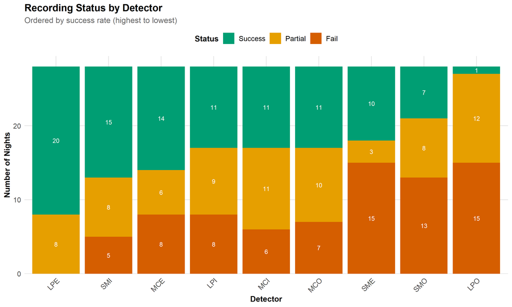

*Recording Status Summary. Generated from standardized pipeline output.*

## 2.2 Recording Status Percent

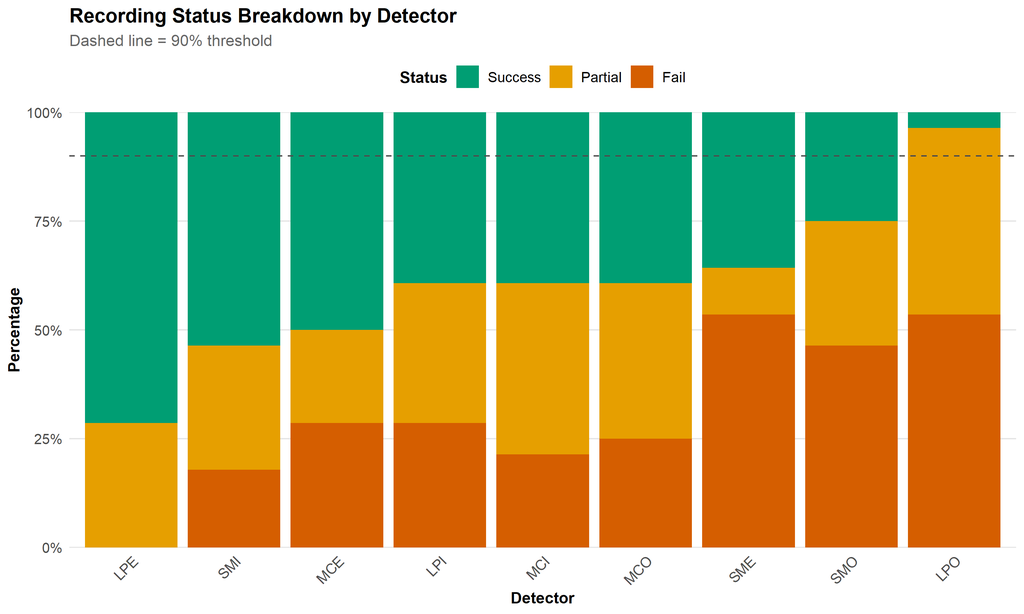

*Recording Status Percent. Generated from standardized pipeline output.*

## 2.3 Recording Status Overall

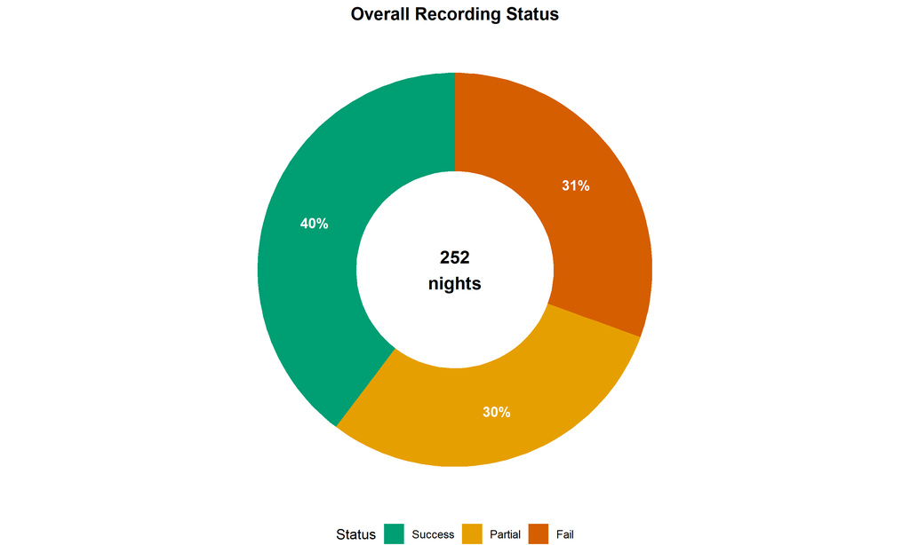

*Recording Status Overall. Generated from standardized pipeline output.*

## 2.4 Effort By Detector

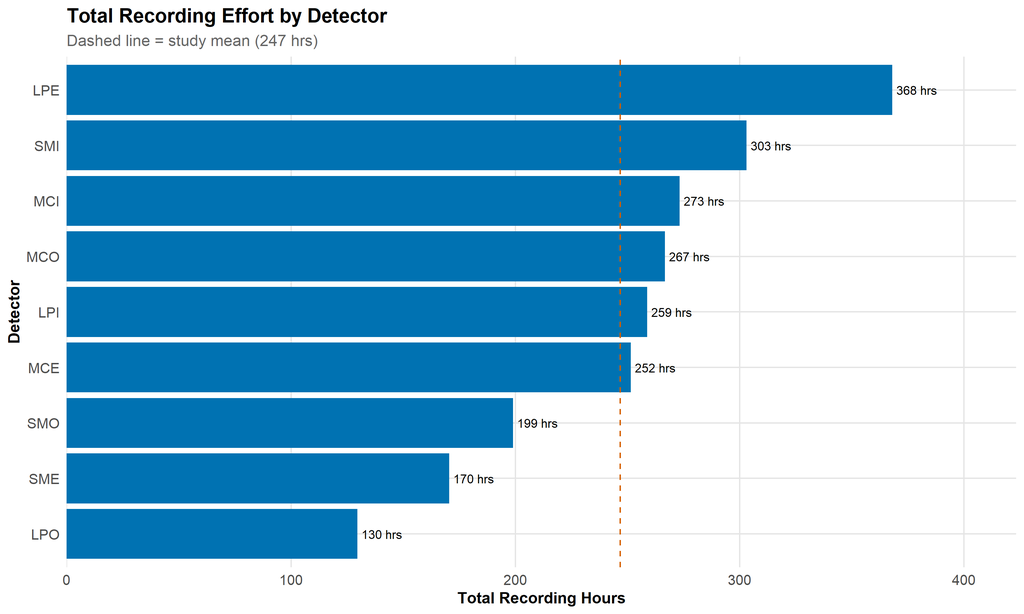

*Effort By Detector. Generated from standardized pipeline output.*

## 2.5 Nights By Detector

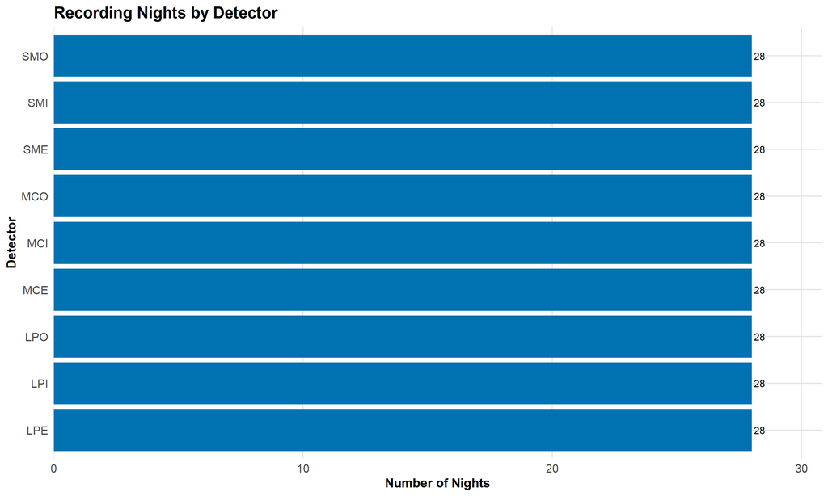

*Nights By Detector. Generated from standardized pipeline output.*

## 2.6 Data Completeness Calendar

[figure not shown]

## 2.7 Missing Nights

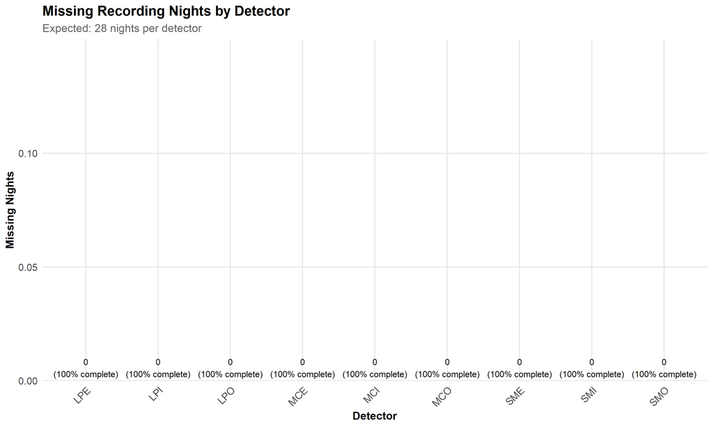

*Missing Nights. Generated from standardized pipeline output.*

## 2.8 Recording Effort Heatmap

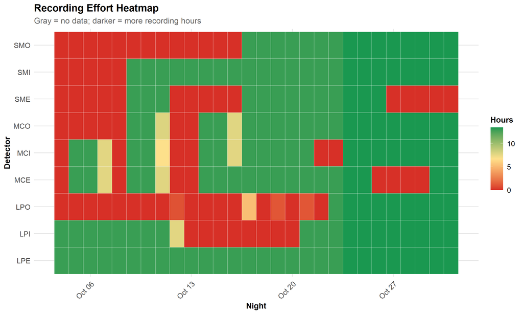

*Recording Effort Heatmap. Generated from standardized pipeline output.*

# 3 Detector Activity

This section presents activity metrics and comparisons across detectors. These visualizations reveal spatial patterns in bat activity and help identify detector-level variation.

## 3.1 Total Calls By Detector

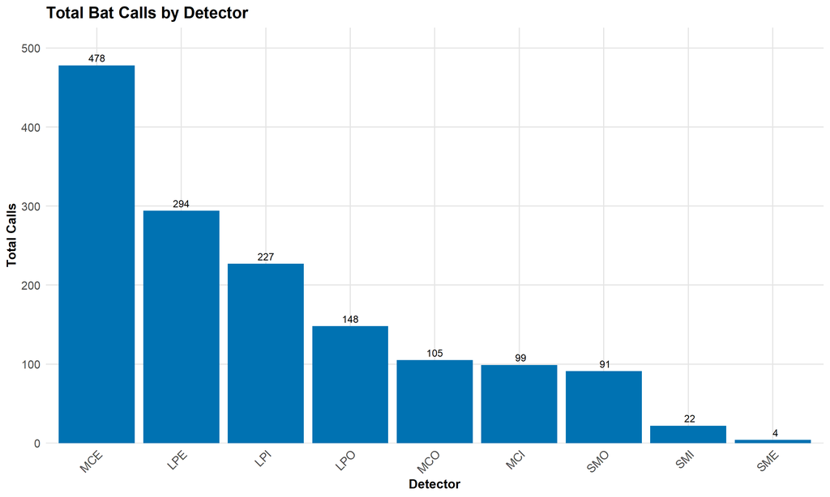

*Total Calls By Detector. Generated from standardized pipeline output.*

## 3.2 Detector Activity Caterpillar

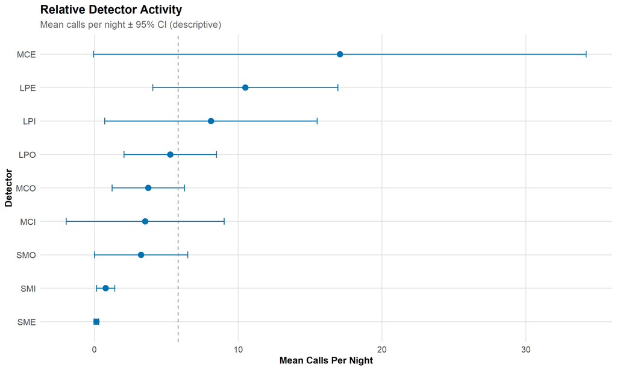

*Detector Activity Caterpillar. Generated from standardized pipeline output.*

## 3.3 Detector Boxplots

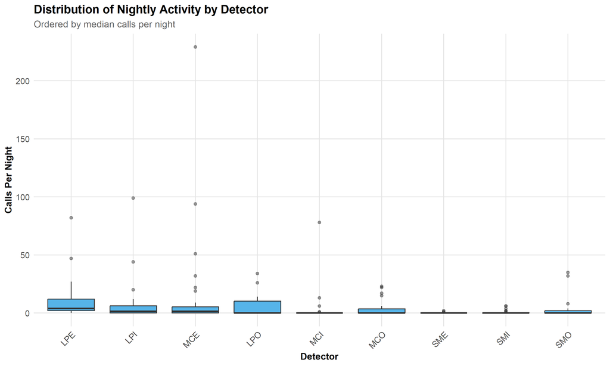

*Detector Boxplots. Generated from standardized pipeline output.*

## 3.4 Activity With Without Outliers

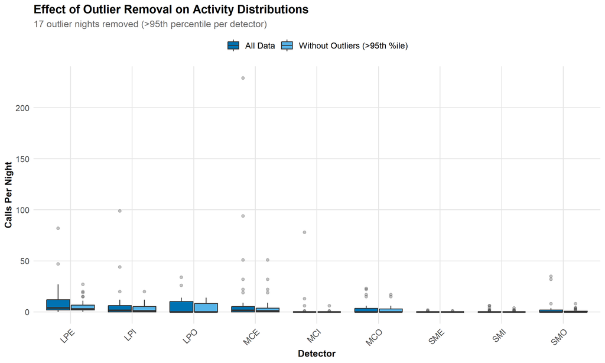

*Activity With Without Outliers. Generated from standardized pipeline output.*

## 3.5 Synchrony

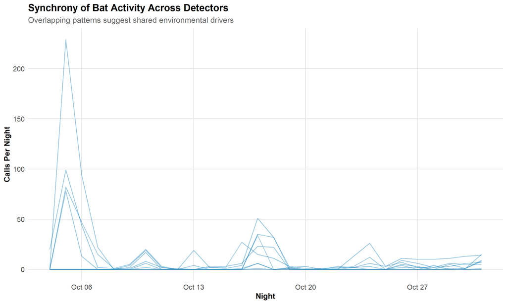

*Synchrony. Generated from standardized pipeline output.*

## 3.6 Correlation Heatmap

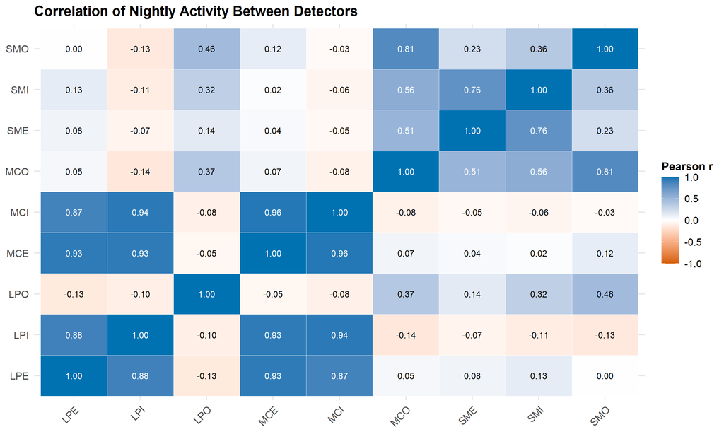

*Correlation Heatmap. Generated from standardized pipeline output.*

## 3.7 Detector Rank Over Time

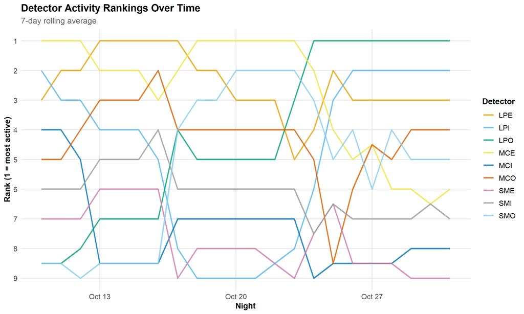

*Detector Rank Over Time. Generated from standardized pipeline output.*

# 4 Species Composition

This section presents species-level detection patterns. Species identifications are based on Kaleidoscope Pro automated classification.

## 4.1 Species Composition Bar

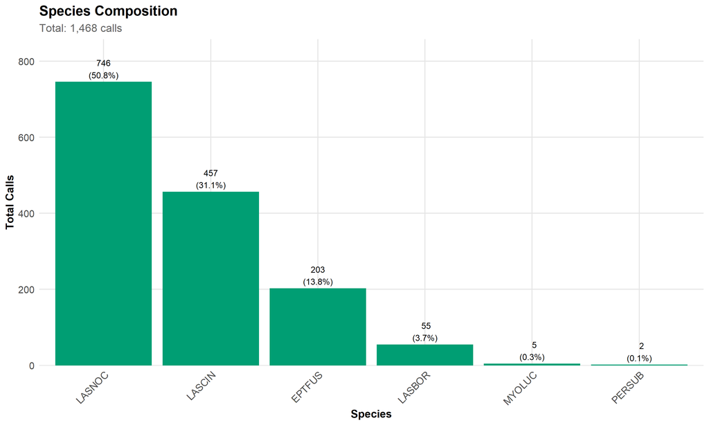

*Species Composition Bar. Generated from standardized pipeline output.*

## 4.2 Species By Detector Heatmap

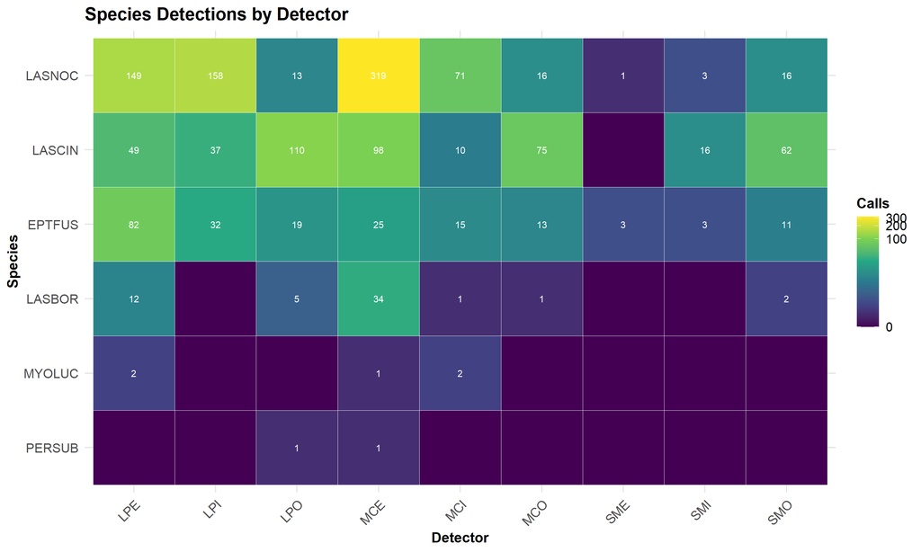

*Species By Detector Heatmap. Generated from standardized pipeline output.*

## 4.3 Species Accumulation Curve

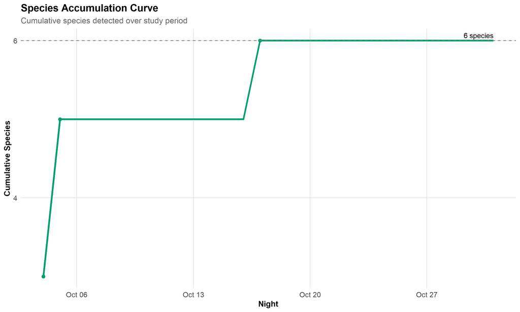

*Species Accumulation Curve. Generated from standardized pipeline output.*

## 4.4 Species Hourly Profile

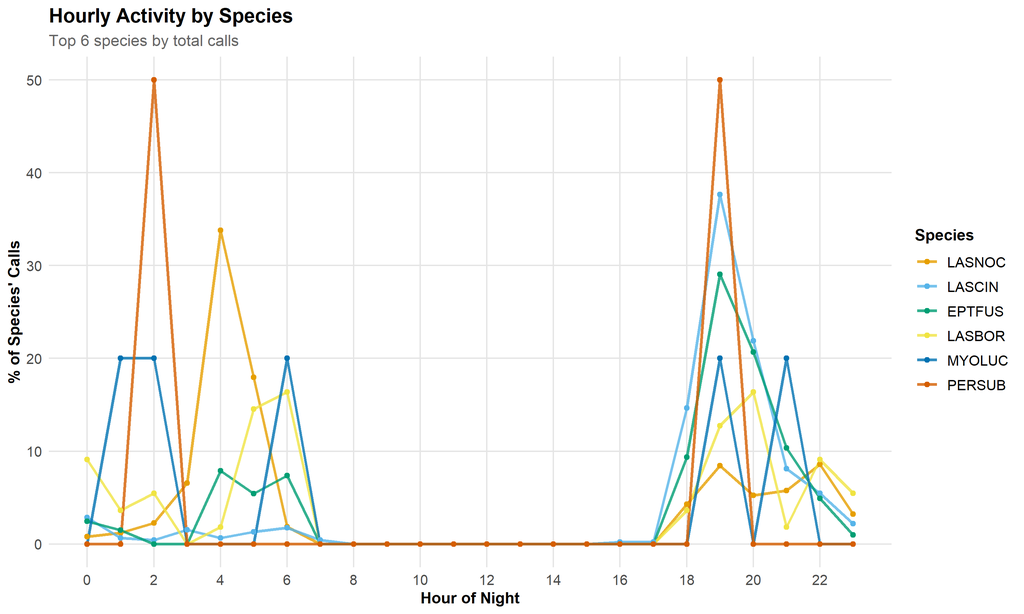

*Species Hourly Profile. Generated from standardized pipeline output.*

## 4.5 Noid Proportion

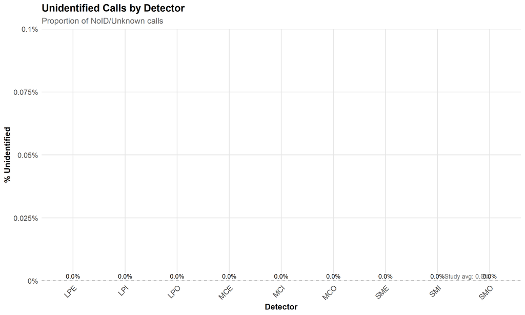

*Noid Proportion. Generated from standardized pipeline output.*

# 5 Temporal Patterns

This section presents temporal activity patterns across the study period. These visualizations reveal when bat activity occurs at different time scales.

## 5.1 Activity Over Time

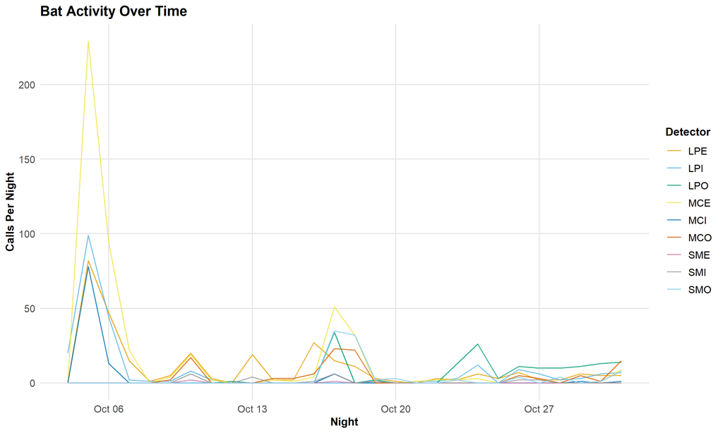

*Activity Over Time. Generated from standardized pipeline output.*

## 5.2 Cumulative Calls Over Time

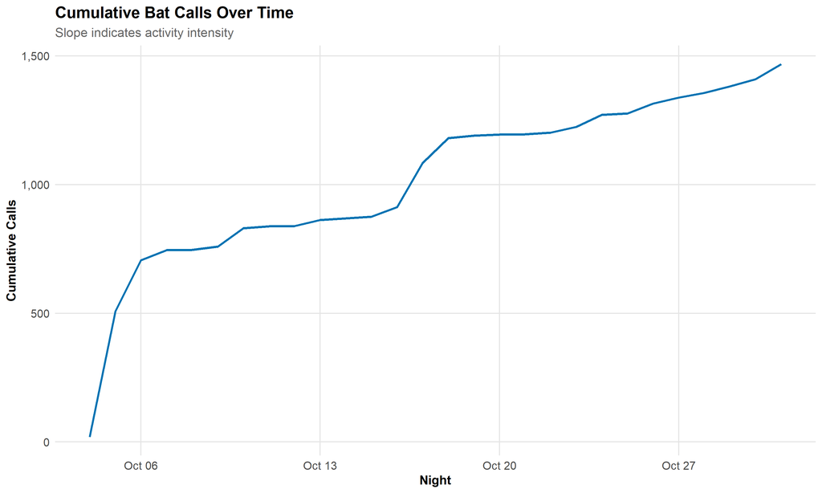

*Cumulative Calls Over Time. Generated from standardized pipeline output.*

## 5.3 Hourly Activity Profile

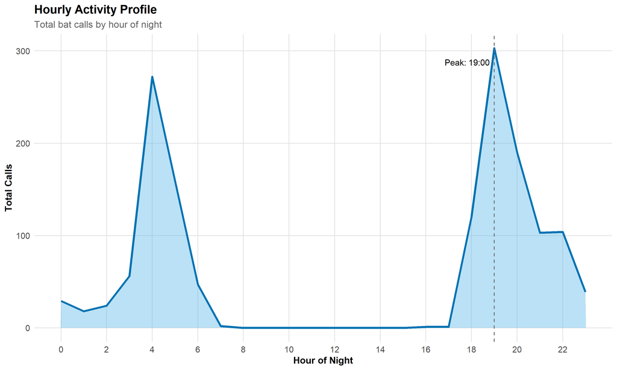

*Hourly Activity Profile. Generated from standardized pipeline output.*

## 5.4 Callsperhour Distribution

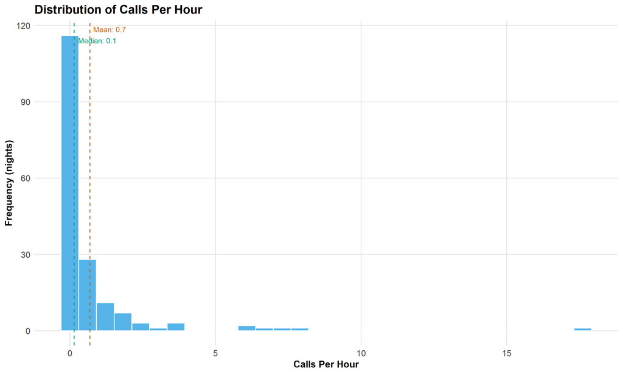

*Callsperhour Distribution. Generated from standardized pipeline output.*

## 5.5 Weekly Activity

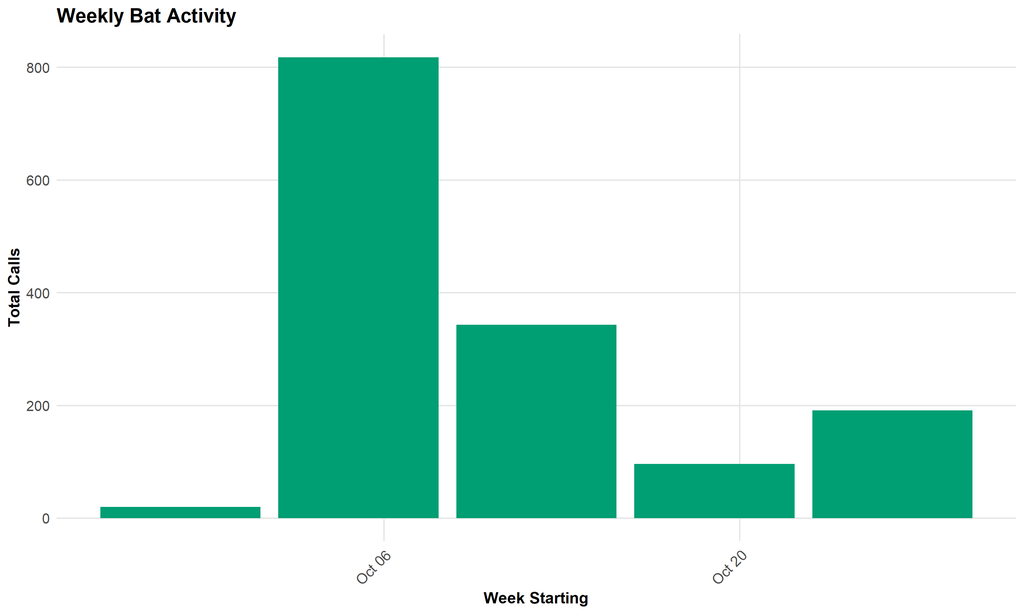

*Weekly Activity. Generated from standardized pipeline output.*

## 5.6 Activity By Month

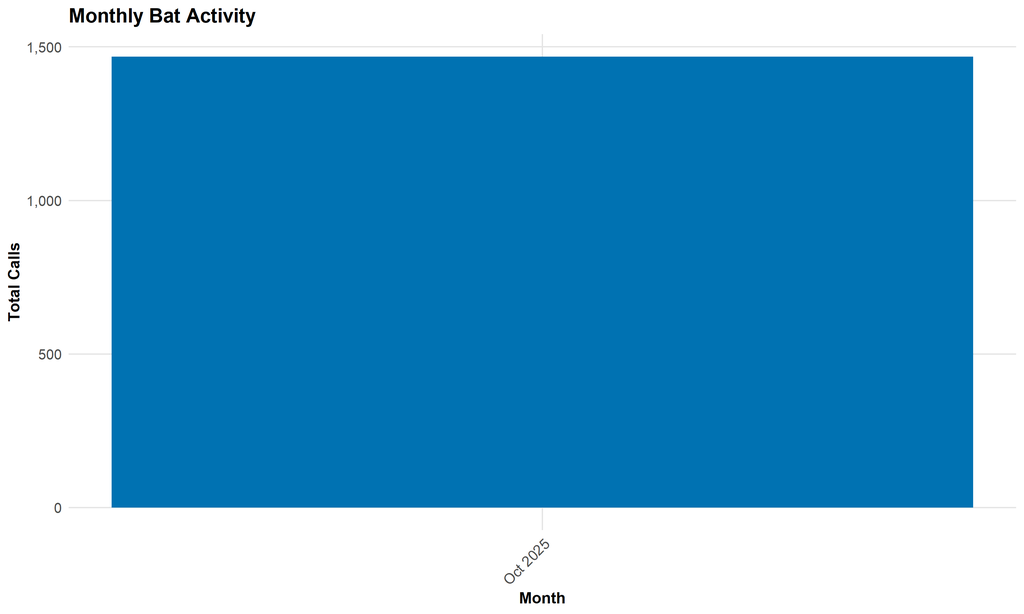

*Activity By Month. Generated from standardized pipeline output.*

# 6 Summary Statistics

This section presents summary statistics tables generated by Workflow 05.

## 6.1 Detector-Level Summary

Table 2

Detector Activity Summary

Key metrics by detector

| Detector | n_nights | total_hours | mean_hours | pct_success | pct_partial | pct_fail | total_calls | mean_cpn | median_cpn | sd_cpn | min_cpn | max_cpn | mean_cph | median_cph | sd_cph | min_cph | max_cph | cv_pct | pct_zero | first_night | last_night |
| --- | --- | --- | --- | --- | --- | --- | --- | --- | --- | --- | --- | --- | --- | --- | --- | --- | --- | --- | --- | --- | --- |
| LPE | 28.00 | 368.00 | 13.10 | 71.40 | 28.60 | 0.00 | 294.00 | 10.50 | 4.00 | 17.40 | 0.00 | 82.00 | 0.80 | 0.30 | 1.34 | 0.00 | 6.31 | 166.50 | 10.70 | 2025-10-04 | 2025-10-31 |
| LPI | 28.00 | 258.70 | 9.20 | 39.30 | 32.10 | 28.60 | 227.00 | 8.10 | 1.50 | 19.90 | 0.00 | 99.00 | 0.87 | 0.23 | 1.77 | 0.00 | 7.62 | 203.80 | 35.70 | 2025-10-04 | 2025-10-31 |
| LPO | 28.00 | 129.60 | 4.60 | 3.60 | 42.90 | 53.60 | 148.00 | 5.30 | 0.00 | 8.70 | 0.00 | 34.00 | 1.34 | 0.96 | 1.61 | 0.00 | 6.44 | 120.20 | 57.10 | 2025-10-04 | 2025-10-31 |
| MCE | 28.00 | 251.50 | 9.00 | 50.00 | 21.40 | 28.60 | 478.00 | 17.10 | 1.50 | 46.20 | 0.00 | 229.00 | 1.90 | 0.24 | 4.12 | 0.00 | 17.62 | 217.10 | 39.30 | 2025-10-04 | 2025-10-31 |
| MCI | 28.00 | 273.30 | 9.80 | 39.30 | 39.30 | 21.40 | 99.00 | 3.50 | 0.00 | 14.80 | 0.00 | 78.00 | 0.35 | 0.00 | 1.28 | 0.00 | 6.00 | 371.10 | 82.10 | 2025-10-04 | 2025-10-31 |
| MCO | 28.00 | 266.70 | 9.50 | 39.30 | 35.70 | 25.00 | 105.00 | 3.80 | 0.00 | 6.80 | 0.00 | 23.00 | 0.40 | 0.15 | 0.58 | 0.00 | 1.77 | 146.50 | 57.10 | 2025-10-04 | 2025-10-31 |
| SME | 28.00 | 170.50 | 6.10 | 35.70 | 10.70 | 53.60 | 4.00 | 0.10 | 0.00 | 0.40 | 0.00 | 2.00 | 0.02 | 0.00 | 0.05 | 0.00 | 0.15 | 204.90 | 89.30 | 2025-10-04 | 2025-10-31 |
| SMI | 28.00 | 303.00 | 10.80 | 53.60 | 28.60 | 17.90 | 22.00 | 0.80 | 0.00 | 1.70 | 0.00 | 6.00 | 0.07 | 0.00 | 0.14 | 0.00 | 0.46 | 196.50 | 75.00 | 2025-10-04 | 2025-10-31 |
| SMO | 28.00 | 199.00 | 7.10 | 25.00 | 28.60 | 46.40 | 91.00 | 3.20 | 0.00 | 8.80 | 0.00 | 35.00 | 0.46 | 0.15 | 0.88 | 0.00 | 2.69 | 188.80 | 67.90 | 2025-10-04 | 2025-10-31 |

## 6.2 Study-Wide Summary

Table 3

Study-Wide Summary Statistics

| Metric | Value |
| --- | --- |
| Number of Detectors | 9 |
| Detector-Nights | 252 |
| Total Recording Hours | 2220.3 |
| Total Calls | 1,468 |
| Overall Mean Calls/Hour | 0.69 |
| Overall Median Calls/Hour | 0.15 |
| Overall SD Calls/Hour | 1.81 |
| Coefficient of Variation (%) | 262.3% |
| % Success Nights | 39.7% |
| % Partial Nights | 29.8% |
| % Fail Nights | 30.6% |

## 6.3 Variance Decomposition

This analysis partitions the total variance in calls per hour into between-detector and within-detector components.

Table 4

Variance Components Analysis

[output not shown]

# 7 Reproducibility Information

This section documents the computational environment and source files used to generate this report, enabling full reproducibility of results.

## 7.1 Session Details

Table 6

Report Generation Details

| Item | Value |
| --- | --- |
| Report Generated | 2026-02-05 15:53:42 CST |
| R Version | 4.5.1 |
| Platform | x86_64-w64-mingw32 |
| Quarto Version | 1.8.26 |
| Summary Data File | summary_data_20260205.rds |
| Plot Objects File | plot_objects_20260205.rds |
| Study Parameters File | study_parameters.yaml |

This report was generated from pre-computed analytical objects:

- **Summary statistics** were computed by Workflow 05 (`05_summary_stats.R`)
- **Plot objects** were generated by Workflow 06 (`06_generate_plots.R`)
- **This report** was rendered by Workflow 07 (`07_generate_report_and_release.R`)

No data transformation, statistical computation, or plot generation occurred during report rendering. All analytical decisions were made in upstream workflows and are documented in the pipeline logs.

*This report was auto-generated by the KPro Masterfile Pipeline. For questions about methodology or data processing, consult the pipeline documentation or contact the study administrator.*